# Lets Explore CUDA

### Contents

1. Introduction to GPU and CUDA
2. CUDA Programming Basics
3. CUDA programming model
4. CUDA Processor
5. CUDA GPU memory

### Introduction to GPU and CUDA

#### CPU vs GPU Performance

In general, a module that processes operations in a computer consists of a CPU specialized in program execution and management of system resources, and a GPU for image processing. Of these, GPU refers to the core in an expansion card, commonly referred to as a graphics card. In the past, it was necessary to install it through a separate card, but these days, as chip attaching technology is developed, most computers are sold as integrated on the mainboard or integrated on the same chipset as the CPU.

[figure not shown]

However, these graphic chipsets include graphic cards that focus on general usage environments (office, web surfing, movies, etc.), and are not enough graphic cards to enjoy games smoothly. Instead, an extended graphic card, that is, a graphic card that continues to be installed in the form of an expansion card in PCs has better graphics computing performance than the aforementioned on-board or on-chip type of graphic chipset.

So, how much better the computing power of the GPU than the CPU?

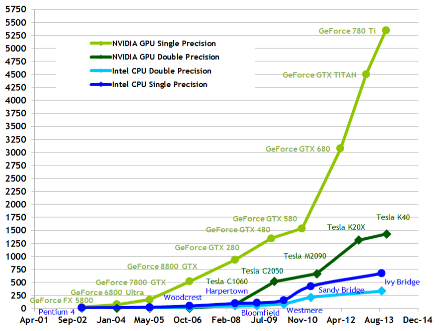

Since the mid-2000s, the performance of GPU has been far higher than that of CPU, because of the constraints that the CPU must have due to the characteristics of the CPU. In the past, increasing the clock speed and increasing the density increased the performance, but Intel alone has encountered a state in which it is difficult to achieve further performance.

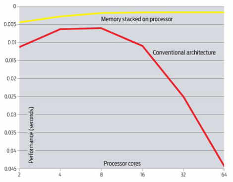

The above data shows the effect of memory on system performance when simulating a Multicore CPU in Sandia. In other words, it means that no matter how good Intel has integrated technology, it is not the best to have a lot of COREs in the PC environment that everyone uses.

But the GPU can go a different way than the CPU. Since there is no need to manage the resources of the system, you can focus on the natural operation of processing data in parallel, and you can configure the operating conditions of the GPU like adding memory to the core as shown in the graph above.

However, even if the performance can be improved in this way, manufacturers cannot help but think about how to sell expensive chipsets for high performance. In addition, from the point of view of several researchers who have been experimenting or simulating using computers, they needed a means to achieve better performance at a lower cost because they had to buy more CPUs and configure clusters.

#### The emergence of GPGPU

The concept of GPGPU (General Purpose Graphic Processing Unit) starts from the fact that the computing power of GPU, which is gradually evolving, can be used for more general purposes in addition to the graphics purpose that has been used so far. In an effort to increase computational performance with SIMD (Single Instruction Multiple Data) instructions in the CPU and overcome the limitations of computational performance through assembly, etc., the GPU can be used as a computational accelerator.

[figure not shown]

Instead, as a development environment suitable for GPGPU emerges, the barrier to entry is lowered so that GPU programming can be used in various research fields as long as it is possible to do C/C++ as well as graphics experts. Starting with nVidia's CUDA, OpenCL and DirectCompute are the main characters.

As you can see from the fact that CUDA is a language developed by nVidia, it only works with nVidia graphics cards. On the other hand, OpenCL is a standard draft from Kronos Group , which publishes OpenGL, etc., so it is supported if it is a chipset that supports parallel support. It is known to have been led by Apple, and typically runs on CPUs from Intel and AMD and GPUs and CPUs from nVidia. DirectCompute was released with DirextX11.

### CUDA Programming Basics

#### Beginning of CUDA programming

Let's make a simple CUDA program so that you can get acquainted with the concept of CUDA programming. Here's what to do

```
#define BUF_SIZE 100

// declaration
pa = new int[BUF_SIZE];
pb = new int[BUF_SIZE];
pc = new int[BUF_SIZE];

// initialise
for (i = 0; i < BUF_SIZE; i++) {
  a[i] = i;
  b[i] = i * BUF_SIZE;
}

// calculation and storage
for (i = 0; i < BUF_SIZE; i++) {
  c[i] = a[i] + b[i];
}

// printing
for (i = 0; i < BUF_SIZE; i++) {
  cout << i << ": " <<c[i]
}

delete [] pa;
delete [] pb;
delete [] pc;
```

If you've played C, you can predict what the result will be just by looking at it. You can combine loops or think that you don't have to do this. The reason I put the code like this is to show you how the above code matches in CUDA, so I will look at the following code and explain it.

```
#define BUF_SIZE 100

__global__ void VedAdd(int *a, int *b, int *c) {
  int idx = blockDim.x * blockIdx.x + threadIdx.x;
  if (idx < BUF_SIZE)
    c[idx] = a[idx] + b[idx];
}

// Declaration
pa = new int[BUF_SIZE];
pb = new int[BUF_SIZE];
pc = new int[BUF_SIZE];

// CUDA Device Memory allocation
int *pda, *pdb, *pdc;
cudaMalloc(&pda, BUF_SIZE * sizeof(int))
cudaMalloc(&pdb, BUF_SIZE * sizeof(int))
cudaMalloc(&pdc, BUF_SIZE * sizeof(int))

// Initialise
for (i = 0; i < BUF_SIZE; i++) {
  a[i] = i;
  b[i] = i * BUF_SIZE;
}

// copying memory
cudaMemcpy(pda, pa, BUF_SIZE * sizeof(int), cudaMemcpyHostToDevice);
cudaMemcpy(pdb, pb, BUF_SIZE * sizeof(int), cudaMemcpyHostToDevice);

// creating thread blocks
int threadsPerBlock = 256;
int blocksPerGrid = (BUF_SIZE + threadsPerBlock - 1) / threadsPerBlock;
VecAdd<<<blocksPerGrid, threadsPerBlock>>>(pda, pdb, pdc);

// copying back
cudaMemcpy(pc, pdc, BUF_SIZE * sizeof(int), cudaMemcpyDeviceToHost);

// printing
for (i = 0; i < BUF_SIZE; i++) {
  cout << i << ": " <<c[i]
}

// deleting the pointers
cudaFree(pda);
cudaFree(pdb);
cudaFree(pdc);

delete [] pa;
delete [] pb;
delete [] pc;
```

Compared to the original operation, the code has increased a lot, which is because the procedures that allocate resources necessary for CUDA to operate are entered into the code.

The differences are as follows:

1. Allocate and free CUDA memory.
2. Data must be copied to CUDA memory.
3. You have to count the number of cuda threads to do what the CPU did by the For problem.
4. In CUDA, functions with the keyword `__global__` run CUDA operations. The detailed grammar will be explained next. However, you only need to understand what steps are involved in performing GPU calculations.

#### Principle of operation

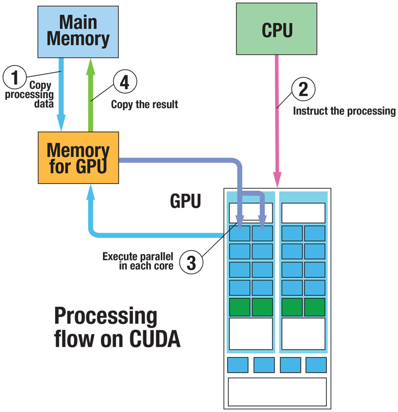

There is a well-explained page, so I linked it to the picture above. As explained earlier, the GPU has a separate memory structure from the CPU and therefore uses a separate memory. Instead of dividing the address space, it is a completely different memory. When you buy a graphics card, you use the memory to display the amount of memory as 1GB, 2GB.., etc. next to it.

Functions such as cudaMalloc and cudaMemcpy shown in the code block above the **CUDA memory** allow our program to reserve memory to be used in the GPU, prepare data for operation, or retrieve operation results. In the figure above, cudaMemcpy plays the role of #1 and #4. The direction of copying can be distinguished as (1)cudaMemcpyHostToDevice, (4)cudaMemcpyDeviceToHost.

Among the differences between **CUDA execution** CPU and CUDA operation, No. 4 was'drive CUDA operation'. That is the content corresponding to No. 3 in the figure above, and it is the role of making the GPU call the specified Kernel function. Then `__global__`, the VecAdd function specified as the keyword in the code above is executed on the GPU.

### CUDA programming model

Multithreading and multiprocessing, which are commonly used as a general parallel processing technique, and various tools provided by the operating system for their full operation could not be understood conceptually, but CUDA operates with different operating conditions on different hardware. Is the same. It's hard to imagine three or four parallel processing, but being able to do hundreds of multithreading feels like an advantage

#### Single Intruction Multiple Thread

The concept of SIMT is a coined word that nVidia borrows from terms used by the CPU to describe its CUDA behavior. In CPU, the term SIMD (Single Instruction Multiple Data) is mainly used, which refers to the operation of processing multiple data with one instruction in order to make the most of the CPU's performance. Similarly, CUDA runs multiple threads with a single command. Then, each CUDA thread processes data one by one, but because CUDA runs multiple threads, it can process multiple data at the same time.

In other words, although the terms and methods are different, SIMD and SIMT have the same purpose: the concept of processing data in parallel. This is an important and basic concept in future CUDA programming, so you need to develop it with the new concept in mind when you encounter or code.

```
__global__ void VecAdd(float* A, float* B, float* C)
{
    int i = blockDim.x * blockIdx.x + threadIdx.x;
    C[i] = A[i] + B[i];
}

int main()
{
...
    // Kernel invocation with N threads
    VecAdd<<<M, N>>>(A, B, C);
...
}
```

Similar CUDA Keywords include `__device__$`, `__host__` and so on. Here's what each means:

| keyword | meaning |
| --- | --- |
| global | Function running on GPU that can be called from CPU main thread |
| host | Function that works only on CPU Thread |
| device | GPU functions that can only be called inside the GPU kernel function |
| host device | Functions that can be called for both CPU/GPU functions |

These CUDA function keywords help the developer to perform the desired operation by letting the CUDA compiler know the object of operation of the code, and it can be said that they play a role in informing developers of the operation conditions of the function.

The important point is that CUDA programming calls the concept of a kernel as a function running on the GPU, and distinguishes between CPU and GPU operations based on this. So, although the source code in the same file, hardware that operates based on keywords can be developed differently.

#### Thread Hierarchy

As previously explained, CUDA has a SIMT structure and operates several threads. However, you don't do it yourself, you have to tell how many threads you have to run.

What you need to know at this time is Thread Hierachy.

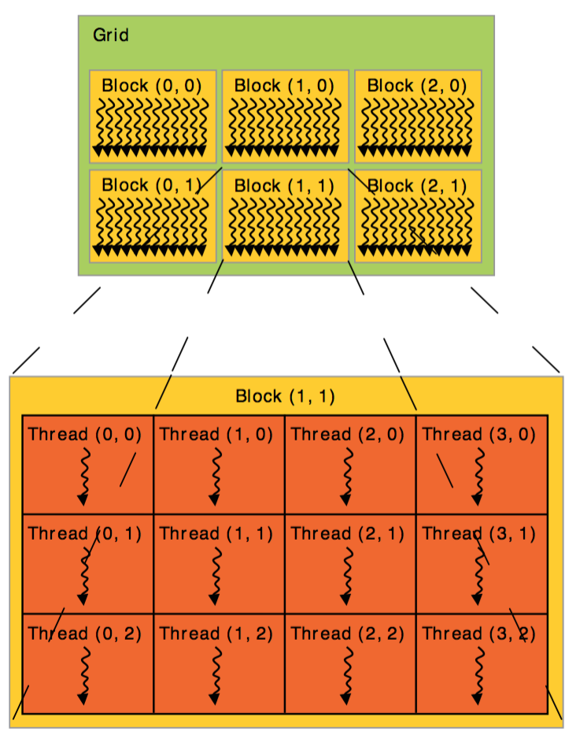

As you can see in the picture, CUDA Thread is operated by being tied to CUDA Block or CUDA Thread Block. And CUDA Block works by being grouped into a unit called Grid again.

Let's check again the example code we used earlier.

```
// Kernel definition
__global__ void MatAdd(float A[N][N], float B[N][N],
                       float C[N][N])
{
    int i = threadIdx.x;
    int j = threadIdx.y;
    C[i][j] = A[i][j] + B[i][j];
}
int main()
{
...
    // Kernel invocation with one block of N * N * 1 threads
    int numBlocks = 1;
    dim3 threadsPerBlock(N, N);
    MatAdd<<<numBlocks, threadsPerBlock>>>(A, B, C);
    ...
}
```

`int i = threadIdx.x;` and `int j = threadIdx.y;` Is the line that designates the index of the CUDA thread as a variable, and `C[i][j] = A[i][j] + B[i][j];` is the part that performs the operation with the thread index learned earlier. Here, the CUDA thread is the thread referred to in the SIMT structure described above, and CUDA provides a threadIdxstructure to distinguish each thread . Therefore, the CUDA thread can know its own index during operation, and determines which data to process based on the index information.

So, how does the CUDA kernel know how many to run? In `<<<numBlocks, threadsPerBlock>>>` knows the answer. The above code is literally In one block, thread는 Run NxN called and passes `<<< ... >>>`the control parameters of the CUDA kernel through.

`<<< ... >>>`Enter the number of CUDA blocks and the block size (the number of CUDA threads). In the above example, the number of blocks is set to 1 and the number of threads is set to NxN. So, can NxN literally be any size?

Actually, this is not the case, and the maximum size is determined by the CUDA hardware specifications, and the optimal size is generally determined. In my experience $N \times N = 256$, this is usually the optimal size. In other words, it's (16)x(16)a story, but it's not that big. So what if you need to process more data than that? In simple terms, we can run the CUDA block we created several times by specifying different data. In CUDA, this operates with the concept of Grid, gridDimand can be specified through. In other words, it informs the CUDA kernel how many times the block should be reused, and CUDA deploys the block in the form of a grid in the figure above, and operates several threads inside the block.

Let me explain with an example showing this. In this example, the NxNdata of a very large dog is processed by CUDA.

```
// Kernel definition
__global__ void MatAdd(float A[N][N], float B[N][N],
float C[N][N])
{
    int i = blockIdx.x * blockDim.x + threadIdx.x;
    int j = blockIdx.y * blockDim.y + threadIdx.y;
    if (i < N && j < N)
        C[i][j] = A[i][j] + B[i][j];
}
int main()
{
...
    // Kernel invocation
    dim3 threadsPerBlock(16, 16);
    dim3 numBlocks(N / threadsPerBlock.x, N / threadsPerBlock.y);
    MatAdd<<<numBlocks, threadsPerBlock>>>(A, B, C);
    ...
}
```

`dim3 threadsPerBlock(16, 16);` If you look at, as I explained a little while ago, the [16, 16]size of the thread block is organized as it is called the general optimal size . And the size of numBlocks was calculated by dividing N by the size of the thread block and how many times the CUDA block should be executed. (The exact calculation is a little different, but this part will be explained more later.) At this time, the two-dimensional index was constructed by calculating each of x and y.

Next, let's take a look at the CUDA Kernel. `int i = blockIdx.x * blockDim.x + threadIdx.x;`,`int j = blockIdx.y * blockDim.y + threadIdx.y;` If you look at, there are keywords you've never seen before. blockIdx, Are blockDimkeywords indicating the index and size of the CUDA thread block. Especially blockDimahead when calling CUDA Kernel `MatAdd<<<numBlocks, threadsPerBlock>>>(A, B, C);` in `<<< ... >>>` has the same value as the control parameters of threadPerBlock haejun passed on. In other words, NxNit is a keyword that allows CUDA to know how to split and process data of the size. By calculating the index value additionally, you can know the index of the CUDA thread and the index of the data to be processed.

To support such complex and diverse indexing, CUDA provides a total of 5 keywords.

| keyword | Explanation | Dimension |
| --- | --- | --- |
| gridDim | Number of kernel blocks | x, y |
| blockIdx | CUAD block index | x, y |
| blockDim | CUDA block size | x, y, z |
| threadIdx | CUDA thread index | x, y, z |
| warpSize | Number of CUDA threads that CUDA Instruction can process at the same time |  |

In other words, there `-Dim`is a keyword named for Grids and Blocks that need to know the size, and a keyword named for Blocks and Threads that need to know the index `-Idx`.

If you combine them well, the CUDA Kernel code can be processed in parallel even if you write code that handles only one thread even if indexing is good. This is how the SIMT structure described earlier is revealed.

Let's list some representative examples of indexing.

[output not shown]

In the table above, the 2nd and 3rd are the same in that they do a 2D index, but the above must use a 2D array, and the 3rd provides 2D indexing for 2D data stored in a 1D array. There is a difference. The third is complicated, so you can change it like this:

```
idx_x = blockDim.x * blockIdx.x + threadIdx.x
idx_y = blockDim.y * blockIdx.y + threadIdx.y
idx = idx_y * Nx + idx_x
```

If you look at it, you can see that it is the same operation as the third in the table, but it has the advantage that you can know exactly what you are trying to do in code, and even if you make a mistake.

Finally, the term Warp came out from the table above. As shown in the table, Warp is the number of CUDA threads that can be processed simultaneously or simultaneously processed by CUDA. To perform parallel processing operation, you can schedule work in units of warp and parallelize as many warps as the number of warps. Warp size may vary according to CUDA Compute Capacity and is usually 32. This size cannot be set variable. However, depending on the contents of the code, the CUDA Thread may be put in a standby state because the warp is not fully utilized, and it is CUDA Occupancy

#### Memory layer

There are two main types of memory layers used by CUDA.

1. Global Memory
   - Memory installed on the graphics card. 1G or more. It is slow compared to other memory. Of course, it's faster than the memory used by the CPU. You have to pay attention to the bandwidth.
2. On-Chip memory
   - Shared L2 Cache: Cache memory shared between CUDA Cores. Not exposed to programming.
   - Shared L1 Cache: L1 Cache used in CUDA Core. (Approximately 64 KB. Varies by core version). Programmable
   - Texture Memory: A read-only cache that supports pre-fetch shared by CUDA Core. Programmable.
   - Constant Memory: A read-only cache that cannot be updated while executing Kernel shared by CUDA Core. Programmable.
   - Register File: Register used by CUDA Thread

Each memory needs a separate explanation, and understanding this well is an important part of optimizing CUDA programming. The picture below is the picture of CUDA Core.

The square picture below is what is called the CUDA Multiprocessor, and above is the interior of what we commonly call the GPU core, which is a bunch of them.

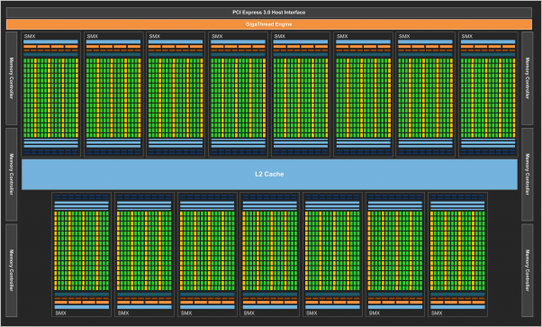

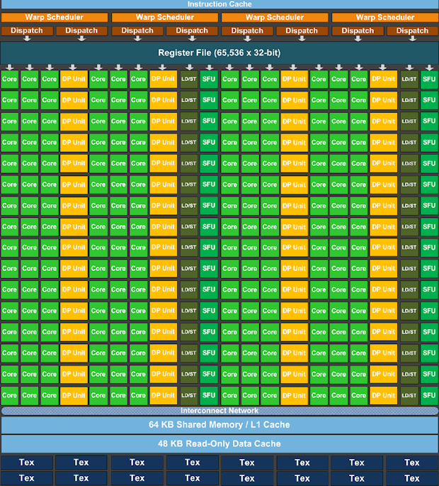

CUDA programming is the interaction between this figure and CUDA Threads. I will explain the structure of CUDA hardware, the relationship between CUDA Threads, and the parts where memory is interlocked in a separate posting.

#### Heterogenious Computing

Heterogeneious Computing refers to a computing method that increases the processing power of a computer through hardware for separate calculations from the former processing all calculations on one core. For example, DSP, FPGA, etc. are used, but CUDA can be said to be similar in that it processes high-performance operations instead of CPU under the control of CPU.

In CUDA, it refers to the procedures necessary for the correct operation of CUDA, such as data transfer between the host memory used by the CPU and the global (device) memory in the graphic card, and kernel calls.

#### Compute Capability

Compute Capability refers to the hardware version of the CUDA core, and is separate from the CUDA version you may have installed for CUDA development. Depending on the version, performance and functions have been improved in various areas such as the size of the cache and the number of cores, and the optimization result may vary slightly accordingly.

For detailed specifications of CUDA Compute Capability, please refer to [CUDA Wikipedia](https://en.wikipedia.org/wiki/CUDA) .

### CUDA Processor

#### CUDA Processor structure

Let's look at the structure of the CUDA Processor. And let's look at how parallel processing is done in CUDA.

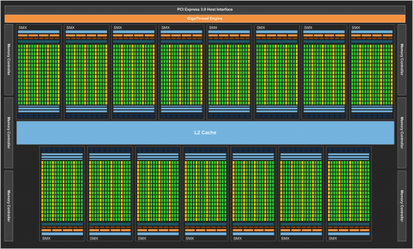

Let's look at it in more detail. The figure below is the structure diagram of CUDA Multi-processor.

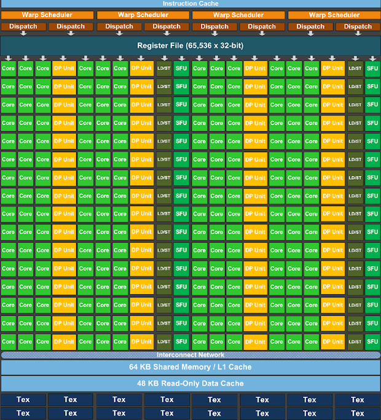

Much of the optimization in CUDA Programming is determined by how well you optimize for this CUDA Multi-Processor. Therefore, you should know about each element someday, but I will move on to the next level from the extent of briefly explaining it here.

- Processing Units
  - Core
    - Processing unit that performs single point operation
    - The reason why CUDA is particularly strong in single floating operation is because there are so many cores that we want to occupy a large number in multi-processor.
  - DP Unit
    - Double Precision Units
    - It is a processing unit that performs double point operation in floating operation. It is used in calculations that require accuracy, and the kernel execution time is longer as the number is small.
  - SFU
    - Special Funciton Units
    - This is the core used in special operations such as sin, cos, and sqrt.
- Control Units
  - Instruction Cache
    - Space to store CUDA Kernel commands
    - When executing the CUDA Kernel, the code is automatically copied to this part, and the CUDA Multi-Core processor individually reads Instructions from this cache and performs operations.
  - Warp Scheduler
    - Warp is Warp's Scheduler, which is the standard for processing jobs in CUDA.
    - Configure warp in CUDA Block and allow CUDA Multi-Processor to successfully execute CUDA Block.
  - Dispatch
    - In order to maximize the performance of CUDA core, CUDA Multi-Processor has multiple dispatches per warp scheduler. The role of Dispatch is to maximize the parallelism of CUDA operations by the number of warps that can be executed simultaneously according to CUDA Occupancy. The way to optimize this is to construct the code through calculation and experimentation of CUDA Occupancy rather than entering the correct number into the coding, and we will deal with it in more detail while dealing with optimization.
- Memory Units
  - Register File
    - A set of registers that CUDA Core can use separately according to the needs of the CUDA Multi-Processor.
    - Since registers are not exclusively configured according to the core, the core can flexibly use the registers as necessary for CUDA Core to perform the kernel.
    - Performance degradation caused by Register Dependency can also be reduced to a minimum.
  - Shared Memory (L1 Cache)
    - L1 Cache that can be shared and used by CUDA Block as much as the size specified in Kernel Code
    - Not exclusive to Core, data is shared between Cores
    - Useful as data with high locality or Read/Write Buffer
  - Read-Only Data Cache
    - Read-only memory, shared in kernel
    - Advantageous to compose a look-up table
  - Tex
    - Read-only pre-fetch cache
    - Helps to effectively read data arranged in 2D or 3D using CUDA Array

In this post, I will focus on the relationship between CUDA Core and Thread Index, so I will only explain the structure up to this point. We will learn about the structure and performance of CUDA Memory by comparing the actual usage and performance while coding through actual examples.

#### Relationship between CUDA Thread Hierachy and CUDA Processor

The logical structure of CUDA Processor and CUDA is correlated as follows.

| CUDA Architecture | CUDA Logical Architecture |
| --- | --- |
| CUDA Processor | CUDA Kernel/Grid |
| CUDA Multi-Processor | Multiple CUDA Blocks |
| CUDA Core | CUDA Thread |

In the previous section, I mentioned that the tasks that need to be processed when executing the CUDA Kernel are divided into CUDA Multi-Processors. At this time, the unit that divides the work is divided into the unit of CUDA Block, and one Multi-Processor processes multiple CUDA Blocks. In addition, with the help of the Warp Scheduler, you can have multiple CUDA Blocks processed sequentially. And CUDA Core each handles CUDA Thread.

In particular, the concept that multiple CUDA Blocks are processed in CUDA Multi-Processor is important because it is related to an important concept in optimization called CUDA Occupancy. CUDA Occupance will be covered in detail in Optimization.

The important point is that CUDA's hardware is structured hierarchically, so CUDA programming is also affected by this layer. That is the background of the concept of CUDA Block, and based on it, CUDA Index is formed.

#### CUDA Thread Index configuration

When developing a CUDA Kernel, it is important to note that the CUDA code you write is a code that is processed in parallel, but from the perspective of CUDA Thread, only one thread is running. Therefore, CUDA Thread has its own index, and to find out this, you need to know the CUDA Thread Indexing Keyword.

While explaining the CUDA Programming model, I briefly explained the keywords for the CUDA Thread Index.

| keyword | Explanation | Dimension |
| --- | --- | --- |
| gridDim | Number of kernel blocks | x, y |
| blockIdx | CUDA block index | x, y |
| blockDim | CUDA block size | x, y, z |
| threadIdx | CUDA thread index | x, y, z |
| warpSize | Number of CUDA threads that CUDA Instruction can process at the same time |  |

Above, I have described the CUDA Architecture in a lengthy manner, and the relationship between it and the CUDA Block and CUDA Thread. This is the explanation needed to explain the logical composition of CUDA Thread Indexing, which will be explained here, and you can understand it only by thinking about the logical composition.

Let me explain with the example. If you cover a $10 \times 18$ space with $[4 \times 4]$ tiles, how many tiles do you need? At this time, the tile cannot be split, it only needs to cover the space.

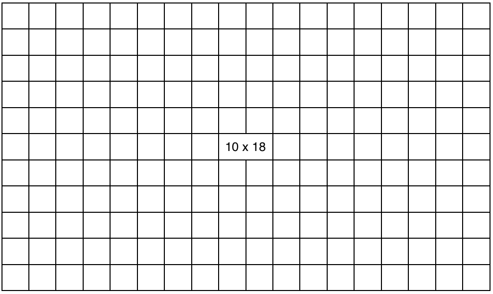

This we will first divide by the size of the block.

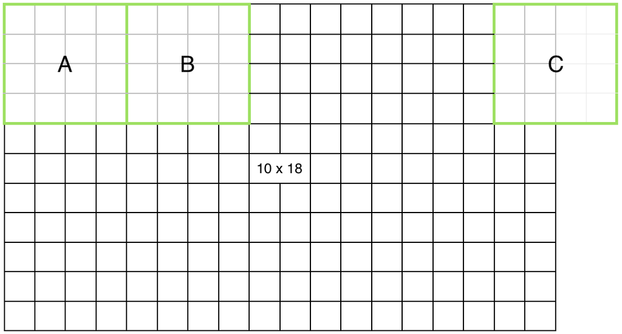

If you simply calculate it as the total number divided by the size of the block, $((10 \times 18) / 4) / 4 = 11.25$ You need a dog, so you might say that the number of tiles you need is 11 or 12. However, it is said that tiles cannot be split, so if you have 5 horizontal and 3 vertical tiles, you will need 15 tiles to cover the $[10 \times 18]$ space with $[4 times 4]$ tiles.

Conceptually, as shown in the figure above, CUDA processes data simultaneously according to the size of the designated CUDA Block as labeled A, B, etc. Then you can cross data boundaries like in C. In CUDA, we can map CUDA Thread to data in the form we want through CUDA Index configuration.

What if the tile size is $[8 \times 2]. 2 \times 9 = 18 Will be a dog.

The method of calculating the size of CUDA's Grid is similar. It cuts the data that needs to be processed to the right size. If data of size $[1920 \times 1080]$ is divided into CUDA blocks of size $[16 \times 16]$, the total number of CUDA blocks is $120 \times 68$.

In this case, width = 1920, height = 1080, block Width = 16, block Height = 16Can be called. The CUDA Keyword is organized as follows.

[output not shown]

Here, just as we set the BlockDim value as [16, 16], we must also set the Grid Dimension so that CUDA can create an appropriate number of CUDA Blocks. Just configure the code. However, the code below is to show the equation, and the size of the block must be passed as a control parameter when calling the kernel as described in CUDA Programming Model.

```
grid_dimension.x = (DATA_WIDTH + blockDim.x - 1) / blockDim.x
grid_dimension.y = (DATA_HEIGHT + blockDim.y - 1) / blockDim.y
```

If you think the above code is complicated, it is good to ceiling it, but it is the same to produce the same result. Anyway, if you do it like the code above, the number of CUDA blocks is variably applied as the data size changes while the size of the CUDA block is fixed.

`blockIdx` The keyword refers to the location of the CUDA block we split earlier, and CUDA Thread `blockIdx` knows the value of to which it belongs , so you can just refer to it.

`threadIdx` Is the index of CUDA threads existing in the CUDA block. blockIdxLikewise, each CUDA thread knows its own CUDA thread index, which can be said to be a relative position. However, for this reason, CUDA Thread needs to know the absolute index address value to know where to process the data

So, when I explained CUDA Programming modeling before, I told you that indexing of CUDA Thread is done as it is while showing the table below.

[output not shown]

The above example of CUDA Indexing is for the case of mapping one CUDA thread per data, and various modifications are possible as needed. If you don't do this, you can change the index more easily and use the CUDA thread index as needed if you modify the index with in mind how the data will be processed per CUDA thread.

### CUDA GPU memory

#### Device memory

Before looking at the memory of CUDA, let's first briefly look at the environment in which CUDA operates. The environment to be developed in the future is an environment that uses computing using more than one processor, called HC (Heterogeneous Computing) or HPC (Heterogeneous Processor Computing). This is another form of programming concept from embedded programming that has an operating environment independent from developing ordinary programs, and you can think of it as having a coprocessor. Let me explain by looking at the picture below.

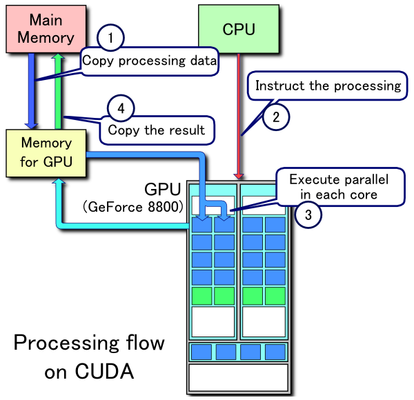

The figure above describes the operation sequence of the CUDA core. First, looking at the components of this figure, there are two processing units and two types of memory. Here, each processing unit has independent memory that it can control and cannot control each other. Therefore, since the GPU code implemented in CUDA can read and write only the GPU memory, there must be a procedure to transfer data to the GPU memory and get the result before and after running the GPU code. In the next section, we'll look at what CUDA provides for this.

[figure not shown]

Therefore, in CUDA, CPU and GPU are considered separately, and CPU is called Host and GPU is called Device. This is because the GPU is also a coprocessor from the point of view of the CPU, and the data is basically in the memory on the CPU side, so it is in the position of the host. Similarly, the memory for CPU is called Host memory and GPU memory is called Device memory.

#### Allocation and initialization

CUDA Host memory allocation is not significantly different from conventional memory allocation.

```
float* h_A = (float*)malloc(size);
```

Device memory is allocated *cudaMalloc* using.

```
float *d_A;
cudaMalloc(&d_A, size);
```

Then, `h_A` and `d_A` are the same size, but memory is allocated to the host and device respectively . So let's look at an example based on this.

#### Free CUDA memory

Then, how do you release the device memory allocated to the GPU memory? For this, CUDA provides a function called *cudaFree*.

```
cudaFree(void* p_mempry);
```

#### Data copy

I mentioned earlier that it is necessary to copy the CUDA memory before executing the CUDA function or to get the result of the CUDA operation. For this, CUDA provides the following functions.

```
cudaMemcpy(void* p_dst, void* p_src, int size, int direct)
```

| Direct | Contents |
| --- | --- |
| memcpyHostToDevice | memcpy Host -> Device |
| memcpyDeviceToHost | memcpy Device -> Host |
| memcpyDeviceToDevice | memcpy Device -> Device |
| memcpyHostToHost | memcpy Host -> Host |

The cudaMemcpy function is a representative memory copy function provided by CUDA. It features predefined parameters that specify the direction of copying. Therefore, you must also pay attention to how you use the memory address when passing it to the function. You can understand it by looking at the code below.

```
cudaMemcpy(d_A, h_A, size, cudaMemcpyHostToDevice);
cudaMemcpy(h_A, d_A, size, cudaMemcpyDeviceToHost);
```

When the data in the host memory is copied to the device memory, the memory allocated by cudaMalloc is transferred to dst and the host memory is transferred to src. Conversely, if you bring the data from the device memory to the host memory, you have to do the opposite. It seems confusing and simple. Then let's check it with a simple example.

```
// Device code
__global__ void VecAdd(float* A, float* B, float* C, int N)
{
  int i = blockDim.x * blockIdx.x + threadIdx.x;
  if (i < N)
    C[i] = A[i] + B[i];
}

// Host code
int main()
{
int N = ...;
  size_t size = N * sizeof(float);
  // Allocate input vectors h_A and h_B in host memory
  float* h_A = (float*)malloc(size);
  float* h_B = (float*)malloc(size);
  // Initialize input vectors
...
  // Allocate vectors in device memory
  float* d_A;
  cudaMalloc(&d_A, size);
  float* d_B;
  cudaMalloc(&d_B, size);
  float* d_C;
  cudaMalloc(&d_C, size);
  // Copy vectors from host memory to device memory
  cudaMemcpy(d_A, h_A, size, cudaMemcpyHostToDevice);
  cudaMemcpy(d_B, h_B, size, cudaMemcpyHostToDevice);
  // Invoke kernel
  int threadsPerBlock = 256;
  int blocksPerGrid =
          (N + threadsPerBlock - 1) / threadsPerBlock;
  VecAdd<<<blocksPerGrid, threadsPerBlock>>>(d_A, d_B, d_C, N);
  // Copy result from device memory to host memory
  // h_C contains the result in host memory
  cudaMemcpy(h_C, d_C, size, cudaMemcpyDeviceToHost);
  // Free device memory
  cudaFree(d_A);
  cudaFree(d_B);
  cudaFree(d_C);
  // Free host memory
... }
```

Here, the device memory is also called global memory. The reason for this redundant term is that it is used repeatedly in the CUDA document. Now, in the context of dealing with on-chip memory, it seems reasonable to name it global from the point of view of the GPU core.

There is also naming that I strongly recommend to those who will be coding CUDA in the future. Host memory starts `h_` with and device memory `d_` starts with. As you might guess, `h_` is the host memory and `d_` is the device memory. Since it is impossible to know where it is allocated with something like a pointer address, it has to be distinguished by a variable name. If you devise and use each other's method, or if there is a method already set by the company, you can follow it, but basically it is recommended to manage it with variable names in this way. In addition, in CUDA programming, it is important to use various types of memory in the right place, so it is useful in many ways to follow this type of naming to distinguish which memory is stored in various types of memories.

#### Shared memory

Shared memory plays the same role as L1 cache among CUDA On-chip memories. The biggest difference from the CPU is that the CPU manages the data in the cache by itself, but the shared memory called CUDA's L1 cache requires you to specify what data to put directly into the CUDA code. The advantages of this configuration are as follows:

1. You can read only as much data as you need.
2. Reduced latency by accessing global memory
3. Optimized global memory bandwidth consumption

### Salutations

1. [CUDA Programming Guide](https://docs.nvidia.com/cuda/cuda-c-programming-guide/index.html)
2. [Intro to Parallel Programming CUDA - Udacity](https://www.youtube.com/playlist?list=PLGvfHSgImk4aweyWlhBXNF6XISY3um82_)